# R Notebook : Analyse des résidus

```r
setwd(dir = "C:/Users/fkraus/Desktop/TD/2026-2027/Econométrie/seance4")
require(readxl)
require(fixest)
require(lmtest)
require(forecast)
require(car)
require(tidyverse)
```

```r
data_schularick <- read_excel("C:/users/fkraus/Desktop/data_schularick.xlsx")

donnees_france <- data_schularick %>%
  filter(country=="France")%>%
  dplyr::select(year, unemp, cpi) %>%
  mutate(inflation = c(NA, diff(log(cpi))))%>%
  mutate(dinflation = c(NA, diff(inflation)))%>%
  mutate(dunemp = c(NA, diff(unemp)))%>%
  na.omit()%>%
  filter(year > 1950)

head(donnees_france)
```

| year | unemp | cpi | inflation | dinflation | dunemp |
| --- | --- | --- | --- | --- | --- |
| 1951 | 2.117500 | 9.611172 | 0.154150680 | 0.060121730 | -0.2016667 |
| 1952 | 2.117500 | 10.772962 | 0.114113307 | -0.040037373 | 0.0000000 |
| 1953 | 2.621667 | 10.561727 | -0.019802627 | -0.133915934 | 0.5041667 |
| 1954 | 2.823333 | 10.561727 | 0.000000000 | 0.019802627 | 0.2016667 |
| 1955 | 2.420000 | 10.667345 | 0.009950331 | 0.009950331 | -0.4033333 |
| 1956 | 1.815000 | 10.984197 | 0.029270382 | 0.019320051 | -0.6050000 |

```r
reg <- feols(inflation ~ dunemp, data=donnees_france)
etable(reg)
```

```
                               reg
Dependent Var.:          inflation

Constant        0.0406*** (0.0046)
dunemp            0.0166* (0.0073)
_______________ __________________
S.E. type                      IID
Observations                    70
R2                         0.07031
Adj. R2                    0.05664
---
Signif. codes: 0 '***' 0.001 '**' 0.01 '*' 0.05 '.' 0.1 ' ' 1
```

# Analyse des résidus

On peut comparer la variable dépendante avec les valeurs prédites par le modèles :

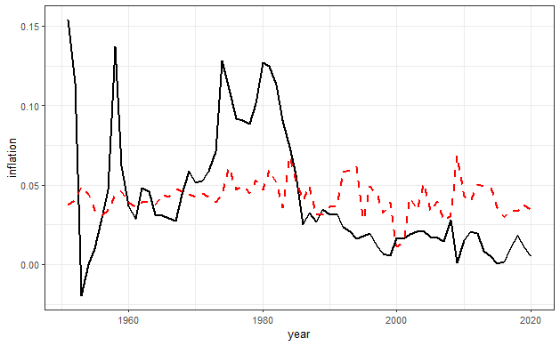

```r
fitted_val <- reg$fitted.values
residuals <- reg$residuals

donnees_france_2 <- donnees_france %>%
  cbind(fitted_val)%>%
  cbind(residuals)
ggplot(donnees_france_2, aes(x=year, y=inflation))+
  geom_line(lwd=1)+
  geom_line(aes(y=fitted_val), color="red", lty=2, lwd=1)+
  theme_bw()
```

On peut voir que notre modèle, bien qu’il utilise des variables correctement stationnarisées, ne représente par correctement la dynamique de la série : les *fitted values* ne suivent pas bien la série d’origine, particulièrement avant les années 1990.

## Homoscedasticité

Pour vérifier l’homoscédasticité (=variance constante dans le temps), on peut déjà fait un graphique des résidus dans le temps.

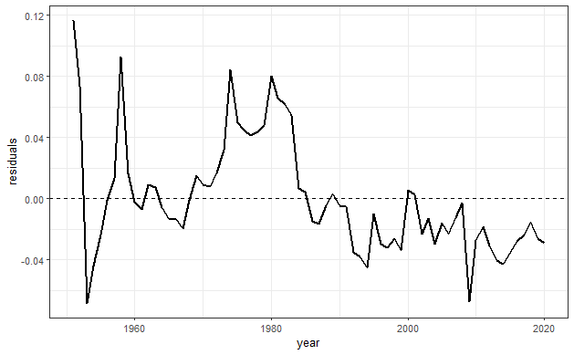

```r
ggplot(donnees_france_2, aes(x=year, y=residuals))+
  geom_line(lwd=1)+
  geom_hline(yintercept = 0, lty=2)+
  theme_bw()
```

On peut voir que la variance des résidus change drastiquement à partir de la fin des années 1980, ce qui pourrait indiquer que les résidus sont hétéroscédastiques. Cependant, l’analyse visuelle n’est pas un test formel. Pour vérifier l’homoscédasticité ou non des résidus, on doit utiliser le test de Breusch-Pagan (BP). Le test BP a pour hypothèse nulle l’homoscédasticité (variance constante des résidus). Si la p-value est significative, on rejette donc l’hypothèse nulle et on conclut de l’hétéroscédasticité. Si la p-value n’est pas significative, on ne rejette pas H0 et il n’y a pas de preuve d’hétéroscédasticité.

```r
require(lmtest)
bptest(inflation ~ dunemp, data=donnees_france)
```

```
    studentized Breusch-Pagan test

data:  inflation ~ dunemp
BP = 4.3177, df = 1, p-value = 0.03772
```

Ici, la p-value est significative, donc on conclut que les résidus de la régression sont hétéroscédastiques.

## Normalité des résidus

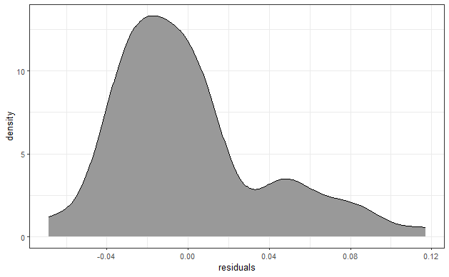

```r
ggplot(donnees_france_2, aes(residuals))+geom_density(fill="grey60", bounds=c(-Inf, Inf))+theme_bw()
```

Les résidus sont bien distribués autour de zéro, et la moyenne est relativement proche de zéro. En revanche, on peut voir que la queue de distribution à droite est relativement large, donc on tend à sous-estimer grandement le modèle à certains moments. La distribution n’est qu’une vérification visuelle, pas un test statistique. Pour un test formel, il faut se tourner vers le test de Shapiro qui teste la normalité d’une série. Le test de Shapiro a pour hypothèse nulle la normalité des résidus. Si la p-value est significative, on rejette donc l’hypothèse nulle, et on conclut de la non-normalité de la série.

```r
shapiro.test(donnees_france_2$residuals)
```

```
    Shapiro-Wilk normality test

data:  donnees_france_2$residuals
W = 0.92324, p-value = 0.0003666
```

Ici, la p-value est significative, donc les résidus ne suivent pas une loi normale selon le test de Shapiro.

On peut visualiser la déviation par rapport a la loi normale avec un **QQ-plot** (quantile-quantile plot). Le QQ-plot compare la distribution empirique des résidus à une distribution normale théorique. Sur l’axe horizontal figurent les quantiles d’une loi normale standard, sur l’axe vertical les quantiles observés des résidus. Si les résidus suivent parfaitement une loi normale, tous les points s’alignent sur la droite diagonale. Tout écart à cette droite signale un écart à la normalité : une courbure en S indique des queues plus épaisses que la normale (leptokurtose), un écart vers le haut à droite ou vers le bas à gauche révèle des valeurs extrêmes inhabituellement grandes.

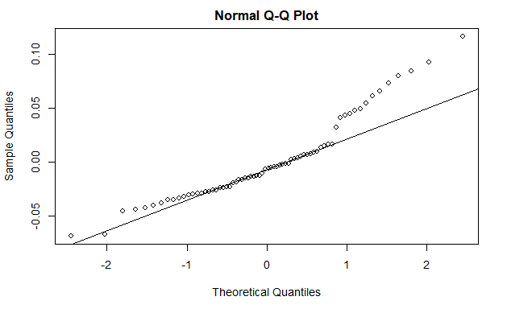

```r
qqnorm(donnees_france_2$residuals)
qqline(donnees_france_2$residuals)
```

## Indépendance

D’après l’hypothèse d’indépendance des résidus, les résidus d’une période ne doivent pas être expliqués par les résidus précédents. On peut tester cette hypothèse avec un simple autocorrélogramme :

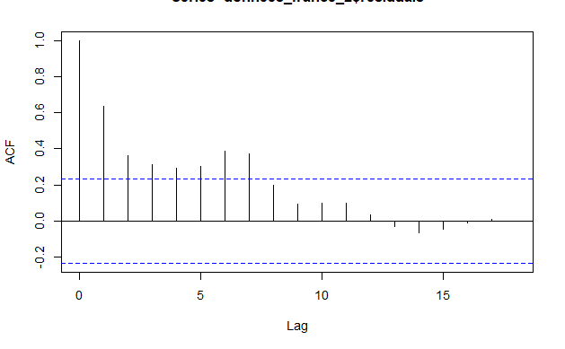

```r
acf(donnees_france_2$residuals)
```

Ici, on observe que les résidus ne semblent pas être indépendants, car les résidus passés expliquent de manière systématique les résidus actuels. Après l’analyse visuel, on peut faire le test formel. Le test Ljung-Box effectue le test d’indépendance des résidus, et a pour hypothèse nulle l’indépendance des résidus. Si la p-value est significative, on rejette l’hypothèse nulle et on conclut de l’autocorrélation (donc, l’absence d’indépendance) des résidus.

```r
Box.test(donnees_france_2$residuals, lag = 10, type = "Ljung-Box")
```

```
    Box-Ljung test

data:  donnees_france_2$residuals
X-squared = 87.576, df = 10, p-value = 1.621e-14
```

Ici, il semble que nos résidus ne sont pas indépendants car la p-value est significative.

*Note : certains de ces tests sont résumés dans la fonction `checkresiduals()` du package `forecast`*:

```
    Ljung-Box test

data:  Residuals from feols
Q* = 87.576, df = 10, p-value = 1.621e-14

Model df: 0.   Total lags used: 10
```

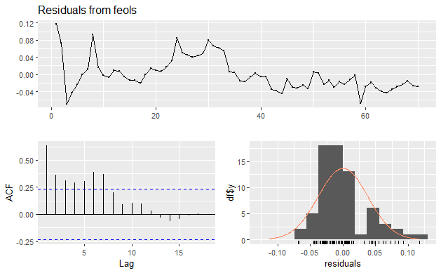

```r
checkresiduals(reg)
```

## Residuals vs Fitted

Un graphique utile pour vérifier que le modèle est bien spécifié est un graphique des résidus avec les *fitted values*, qui permet de vérifier deux hypothèses fondamentales de la régression OLS simultanément. D’abord, si les résidus forment un nuage aléatoire centré sur zéro sans structure apparente, cela confirme que la relation estimée est correctement spécifiée : une courbure ou un pattern systématique (en U, en arc) indiquerait que la relation entre $X$ et $Y$ n’est pas linéaire, et qu’il faudrait transformer les variables ou ajouter des termes polynomiaux.

Ensuite, ce graphique est un diagnostic visuel de l’homoscédasticité : si la dispersion verticale des résidus augmente (ou diminue) à mesure que $\hat Y_t$ augmente - formant un entonnoir - cela suggère que la variance des résidus dépend du niveau de la variable expliquée, ce qui viole l’hypothèse d’homoscédasticité.

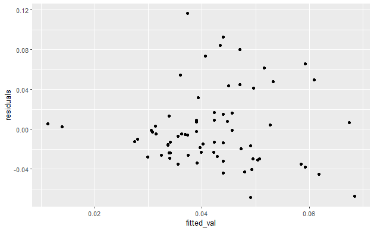

# Overfitting

Parfois, on peut ajouter des variables qui vont créer un biais de collinéarité : les variables explicatives peuvent s’influencer entre elles, ou avoir un effet circulaire avec la variable dépendante, ce qui va créer un problème dans la régression.

```r
reg_colin <- feols(inflation ~dunemp + lag(inflation), data= donnees_france)
etable(reg_colin)
```

```
                       reg_colin
Dependent Var.:        inflation

Constant        0e-16 (2.22e-18)
dunemp          0e-16 (2.51e-18)
lag(inflation)  1.000*** (4e-17)
_______________ ________________
S.E. type                    IID
Observations                  70
R2                             1
Adj. R2                        1
---
Signif. codes: 0 '***' 0.001 '**' 0.01 '*' 0.05 '.' 0.1 ' ' 1
```

Ici on a un $R^2$ égal à 1, signifiant qu’on prédit 100% de la variabilité de l’inflation. Et quand on regarde l’écart entre les *fitted valued* et la variable dépendante, on obtient :

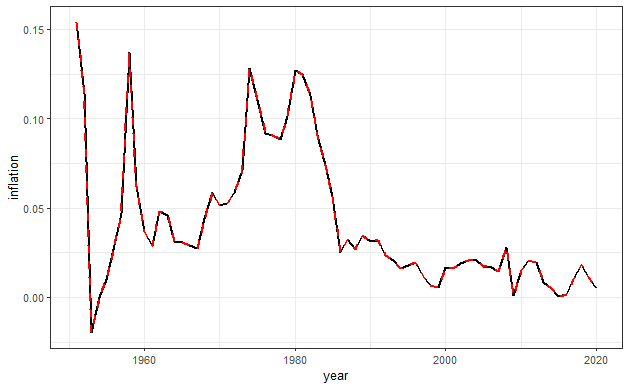

```r
fitted_val_colin <- reg_colin$fitted.values
residuals_colin <- reg_colin$residuals

donnees_france_3 <- donnees_france %>%
  cbind(fitted_val_colin)%>%
  cbind(residuals_colin)
ggplot(donnees_france_3, aes(x=year, y=inflation))+
  geom_line(lwd=1)+
  geom_line(aes(y=fitted_val_colin), color="red", lty=2, lwd=1)+
  theme_bw()
```

On peut tester la collinéarité avec un test VIF

```r
vif(reg_colin)
```

```
                  GVIF Df GVIF^(1/(2*Df))
dunemp         1.07563  0             Inf
lag(inflation) 1.07563  0             Inf
```

Ici, le GVIF corrigé (colonne à droite) tend vers l’infini. On essaie en général de garder un VIF **au maximum** a 6 ou 7, au delà il y a un problème.